```r
setwd("~/Desktop")
getwd()
```

```
## [1] "/Users/mert/Desktop"
```

```r
library(data.table)
library(ggplot2)
library(lubridate)
library(readxl)
library(forecast)
library(urca)
```

Introduction

The ability to predict and guide the factors such as consumption and production are one of the steps to observe the market and plan ahead. In this analysis I have manipulated the data of daily electric consumption data of Turkey.

```r
daily_data <- read.csv("homework_4.csv")
#daily_data = daily_datadd[,c(1,2,3)]


#daily_data = data.table(data[ , c(1:3)])

#format =  "%d.%m.%y"


daily_data = as.data.table(daily_data)
daily_data[, index := c(1:.N)]


daily_data1 = daily_data[ index%%24 == 1 ]

daily_data = daily_data1


daily_data[, Month := as.factor(month(Date))]
daily_data[, Day := as.factor(day(Date))]


daily_data$Date = as.Date(daily_data$Date)
daily_data
```

```
##             Date Hour Consumption    T_1   T_2   T_3    T_4    T_5    T_6   T_7
##    1: 2017-01-01    0    25409.31 -15.88  4.18  0.89 -18.96 -14.77 -10.68  2.16
##    2: 2017-01-02    0    25453.16  -4.55  3.60  2.20 -10.89 -12.48 -11.78  3.06
##    3: 2017-01-03    0    28723.47 -17.41  5.97  3.94 -15.87 -12.10  -9.68  5.82
##    4: 2017-01-04    0    28988.88 -13.05  4.35  8.85 -14.65 -10.05  -9.45  7.55
##    5: 2017-01-05    0    29093.63  -1.83  6.13 10.55  -3.19  -2.28  -6.74  8.67
##   ---
## 1464: 2021-01-03    0    29643.70   1.85 12.58 10.70   2.64   4.77   2.62 12.43
## 1465: 2021-01-04    0    30082.14   2.09 12.31 10.38   2.67   4.38   3.51 13.16
## 1466: 2021-01-05    0    33465.78   1.53 11.36 14.34   3.54   5.13   3.52 13.11
## 1467: 2021-01-06    0    33558.82   5.22 10.66 10.77   4.01   3.74   1.63 11.95
## 1468: 2021-01-07    0    34098.38   3.08 12.05 10.10   4.14   3.88   3.00 11.99
##       index Month Day
##    1:     1     1   1
##    2:    25     1   2
##    3:    49     1   3
##    4:    73     1   4
##    5:    97     1   5
##   ---
## 1464: 35113     1   3
## 1465: 35137     1   4
## 1466: 35161     1   5
## 1467: 35185     1   6
## 1468: 35209     1   7
```

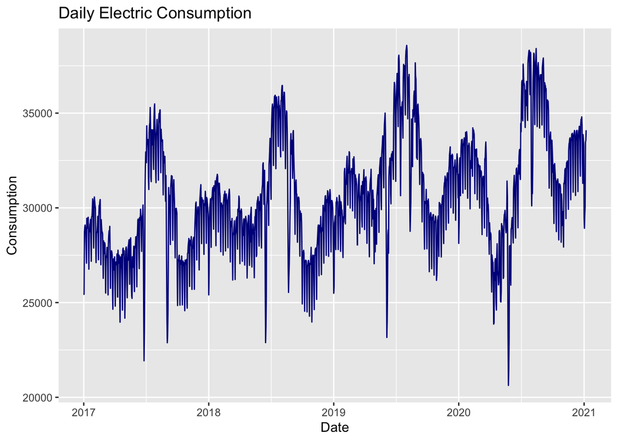

```r
ggplot(daily_data) + geom_line(aes( x= Date , y = Consumption) , color = "dark blue") + labs(title = "Daily Electric Consumption  ", x = " Date ", y = " Consumption ")
```

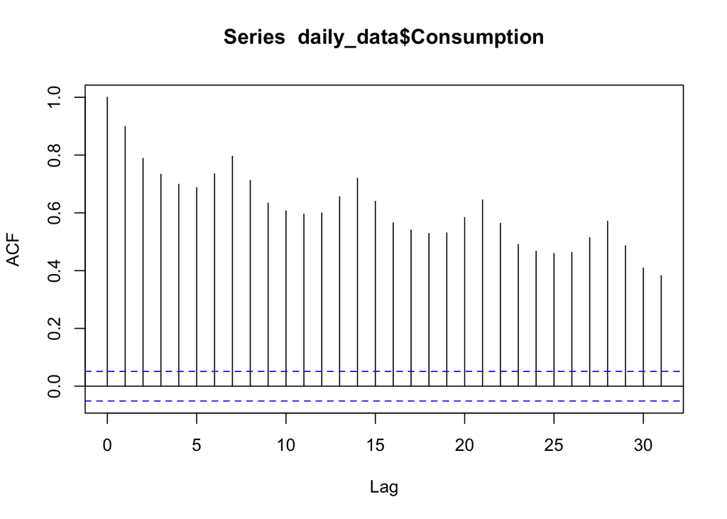

```r
acf(daily_data$Consumption)
```

The Data

As can be seen from the graphs, we have a highly seasonilized data over the months and weeks, therefore we observe high autocorrelations over the data set.

Seasonal Differencing

In order to remove the affect of obvious weekly seasonality, I have shifted the consumption data with 7 lags and checked the differences between previous week. Then I added this differences to a new column. Below, there is the graph of 7 lag differencing.

```r
Box.test(daily_data$Consumption, lag=10, type="Ljung-Box")
```

```
##
##  Box-Ljung test
##
## data:  daily_data$Consumption
## X-squared = 7931.7, df = 10, p-value < 2.2e-16
```

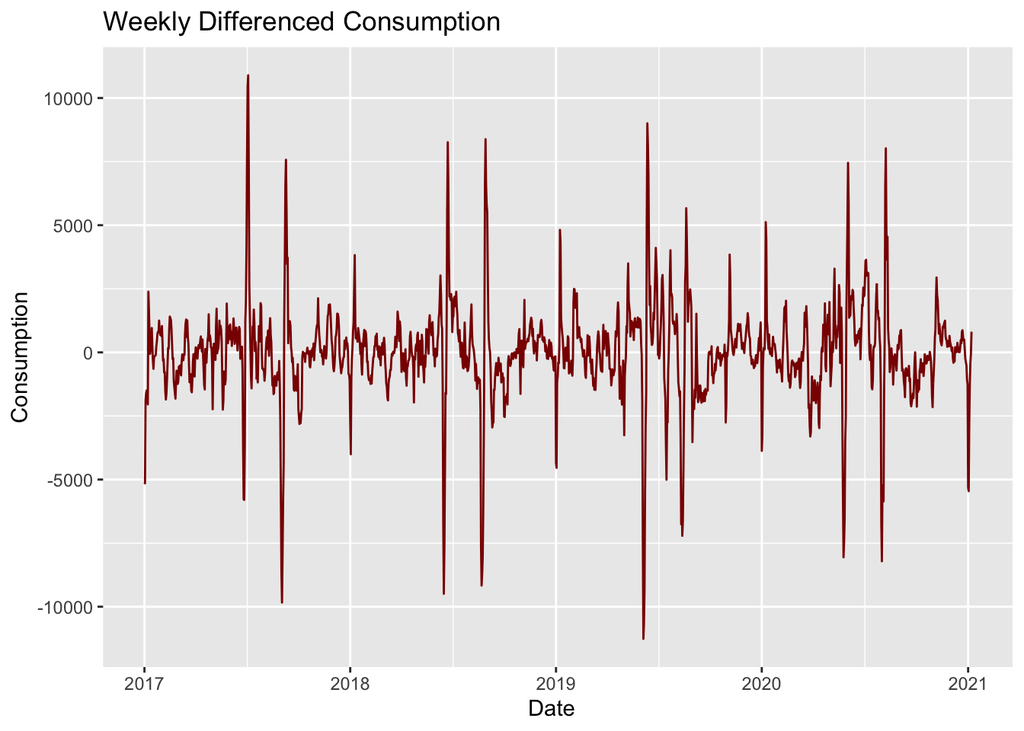

```r
#it is not stationary


daily_data[ , lag7 := shift(x = daily_data$Consumption , n = 7L , fill = mean(daily_data$Consumption))]

daily_data[ , lag7_diff := daily_data$Consumption - daily_data$lag7]


ggplot(daily_data) + geom_line( aes( y = daily_data$lag7_diff , x = daily_data$Date) , color = "dark red") + labs(title = "Weekly Differenced Consumption   ", x = "Date  ", y = " Consumption ")
```

Handling the Outlyers

For we have studied the same data set for the project as well, I have determined which dates have extraordinary behavior for being a special date, and then replace the special dates’ observation with the exactly previous weeks’ observations. Yielding graph is as follows,

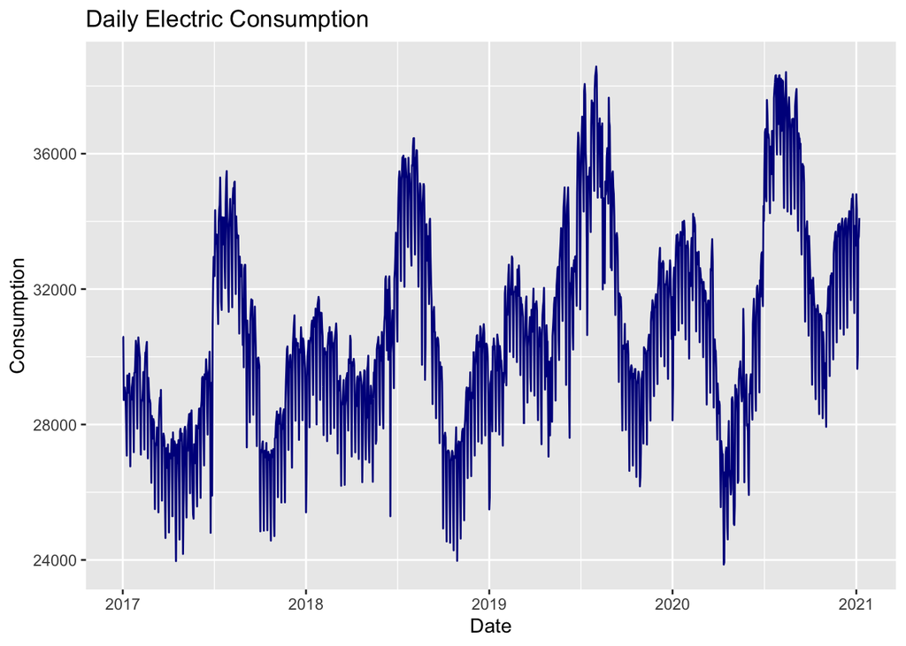

```r
daily_data[  lag7_diff < - 5050]$Consumption = daily_data[  lag7_diff < - 5050]$Consumption - daily_data[  lag7_diff < - 5050]$lag7_diff


daily_data[ , lag7 := shift(x = daily_data$Consumption , n = 7L , fill = mean(daily_data$Consumption))]

daily_data[ , lag7_diff := daily_data$Consumption - daily_data$lag7]

ggplot(daily_data) + geom_line(aes( x= Date , y = Consumption) , color = "dark blue") + labs(title = "Daily Electric Consumption  ", x = " Date ", y = " Consumption ")
```

Checking the Stationary and Autocorrelations

By checking one week differenced series by using KPSS test and Ljung-Box test, we can conclude that it might be considered as Stationary, but it still has some degree of autocorrelation which can be utilized in order to make more accurate predictions.

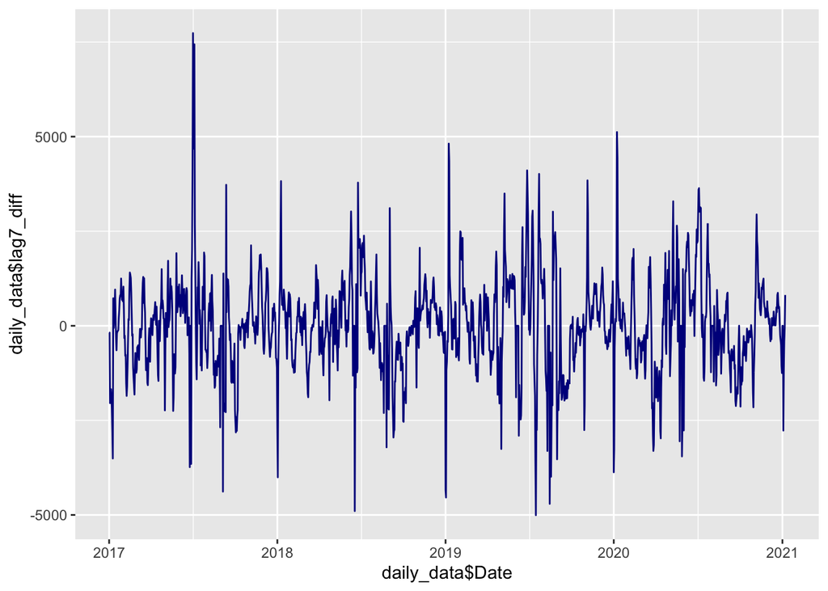

```r
ggplot(daily_data) + geom_line( aes( y = daily_data$lag7_diff , x = daily_data$Date) , color = "dark blue")
```

```r
summary(ur.kpss(daily_data$lag7_diff) )
```

```
##
## #######################
## # KPSS Unit Root Test #
## #######################
##
## Test is of type: mu with 7 lags.
##
## Value of test-statistic is: 0.0375
##
## Critical value for a significance level of:
##                 10pct  5pct 2.5pct  1pct
## critical values 0.347 0.463  0.574 0.739
```

```r
Box.test(daily_data$lag7_diff, lag=30, type="Ljung-Box")
```

```
##
##  Box-Ljung test
##
## data:  daily_data$lag7_diff
## X-squared = 1863.8, df = 30, p-value < 2.2e-16
```

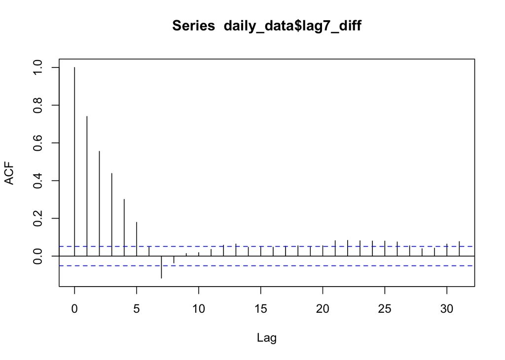

```r
acf(daily_data$lag7_diff)
```

ARIMA Model 1

Since we observed high autocorrelations up to lag 7 on the 7 lag shifted difference data, in my arima model I have used autocorrelation lags as 14, and checked the residuals.

```r
model1 = arima(daily_data$Consumption , order = c(14,0,0))
summary(model1)
```

```
##
## Call:
## arima(x = daily_data$Consumption, order = c(14, 0, 0))
##
## Coefficients:
##          ar1      ar2     ar3      ar4     ar5     ar6     ar7      ar8
##       0.7353  -0.0465  0.1364  -0.0294  0.0016  0.0564  0.6280  -0.5354
## s.e.  0.0258   0.0323  0.0324   0.0326  0.0326  0.0326  0.0293   0.0292
##           ar9     ar10    ar11     ar12    ar13    ar14  intercept
##       -0.0108  -0.0967  0.0279  -0.0371  0.0095  0.1424  30775.931
## s.e.   0.0325   0.0326  0.0327   0.0326  0.0326  0.0261   1040.179
##
## sigma^2 estimated as 635006:  log likelihood = -11894.65,  aic = 23821.3
##
## Training set error measures:
##                    ME     RMSE      MAE         MPE     MAPE      MASE
## Training set 4.936634 796.8727 540.1845 -0.05454301 1.775989 0.5532635
##                    ACF1
## Training set 0.04675368
```

```r
daily_data[, fitted1 := fitted(model1)]
daily_data[, residuals1 := residuals(model1)]
```

ARIMA Model 1 Residuals

```r
acf(residuals(model1))

Box.test(daily_data$residuals1, lag=7, type="Ljung-Box")
```

```
##
##  Box-Ljung test
##
## data:  daily_data$residuals1
## X-squared = 67.749, df = 7, p-value = 4.206e-12
```

```r
summary(ur.kpss(daily_data$residuals1) )
```

```
##
## #######################
## # KPSS Unit Root Test #
## #######################
##
## Test is of type: mu with 7 lags.
##
## Value of test-statistic is: 0.1925
##
## Critical value for a significance level of:
##                 10pct  5pct 2.5pct  1pct
## critical values 0.347 0.463  0.574 0.739
```

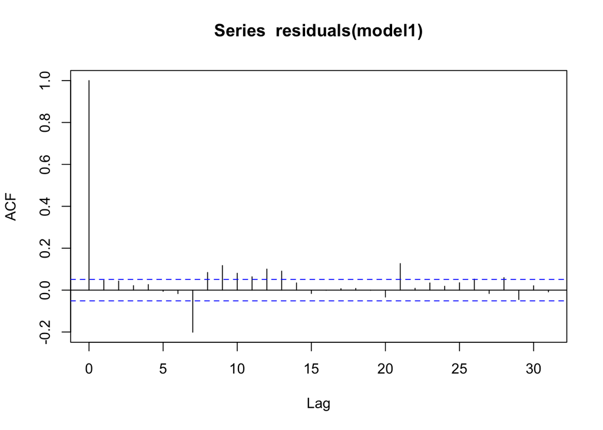

```r
daily_data[ , residuals1 := residuals(model1)]
daily_data[ , fitted1 :=  fitted(model1)]

acf(residuals(model1))
```

ARIMA Model 2

```r
model2 = auto.arima(daily_data$residuals1 )
summary(model2)
```

```
## Series: daily_data$residuals1
## ARIMA(0,0,0) with zero mean
##
## sigma^2 estimated as 635006:  log likelihood=-11890.26
## AIC=23782.52   AICc=23782.53   BIC=23787.82
##
## Training set error measures:
##                    ME     RMSE      MAE MPE MAPE      MASE       ACF1
## Training set 4.936634 796.8727 540.1845 100  100 0.7686706 0.04675368
```

```r
daily_data[ , residuals2 := residuals(model2) ]
daily_data[ , fitted2 :=   fitted(model1) + residuals(model2)]
```

ARIMA Model 2 Residuals

```r
Box.test( (daily_data$residuals2  )  , lag=7, type="Ljung-Box")
```

```
##
##  Box-Ljung test
##
## data:  (daily_data$residuals2)
## X-squared = 67.749, df = 7, p-value = 4.206e-12
```

```r
summary(ur.kpss(daily_data$residuals2) )
```

```
##
## #######################
## # KPSS Unit Root Test #
## #######################
##
## Test is of type: mu with 7 lags.
##
## Value of test-statistic is: 0.1925
##
## Critical value for a significance level of:
##                 10pct  5pct 2.5pct  1pct
## critical values 0.347 0.463  0.574 0.739
```

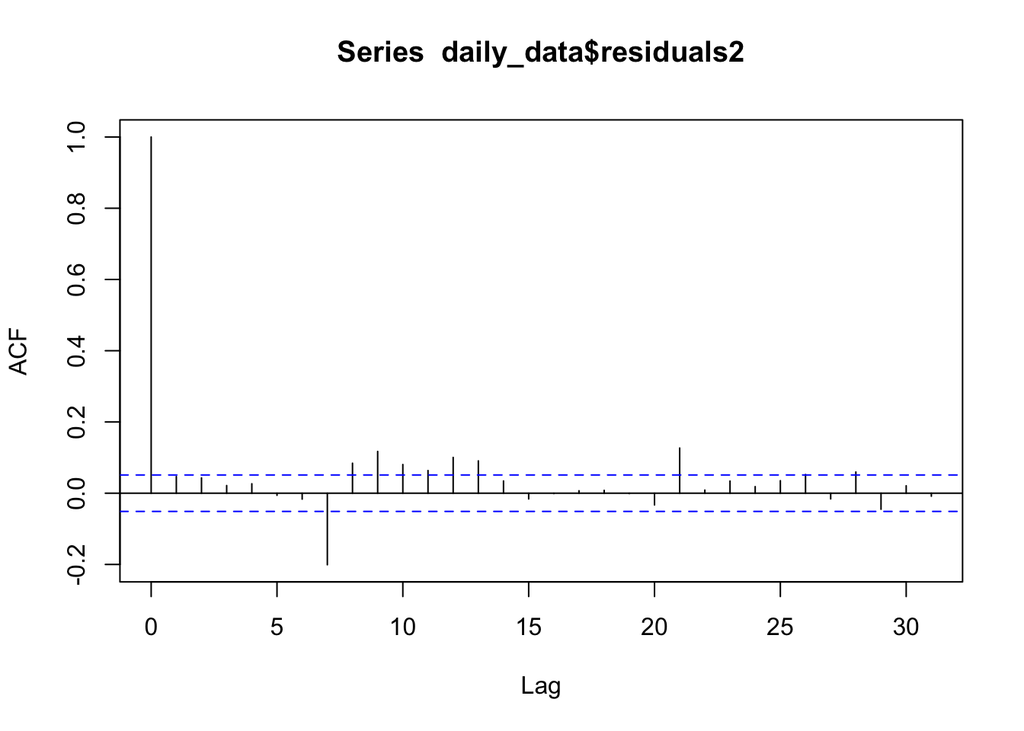

```r
acf(daily_data$residuals2)
```

ARIMA Model 3

```r
model3 =  auto.arima(daily_data$residuals2)
summary(model3)
```

```
## Series: daily_data$residuals2
## ARIMA(0,0,0) with zero mean
##
## sigma^2 estimated as 635006:  log likelihood=-11890.26
## AIC=23782.52   AICc=23782.53   BIC=23787.82
##
## Training set error measures:
##                    ME     RMSE      MAE MPE MAPE      MASE       ACF1
## Training set 4.936634 796.8727 540.1845 100  100 0.7686706 0.04675368
```

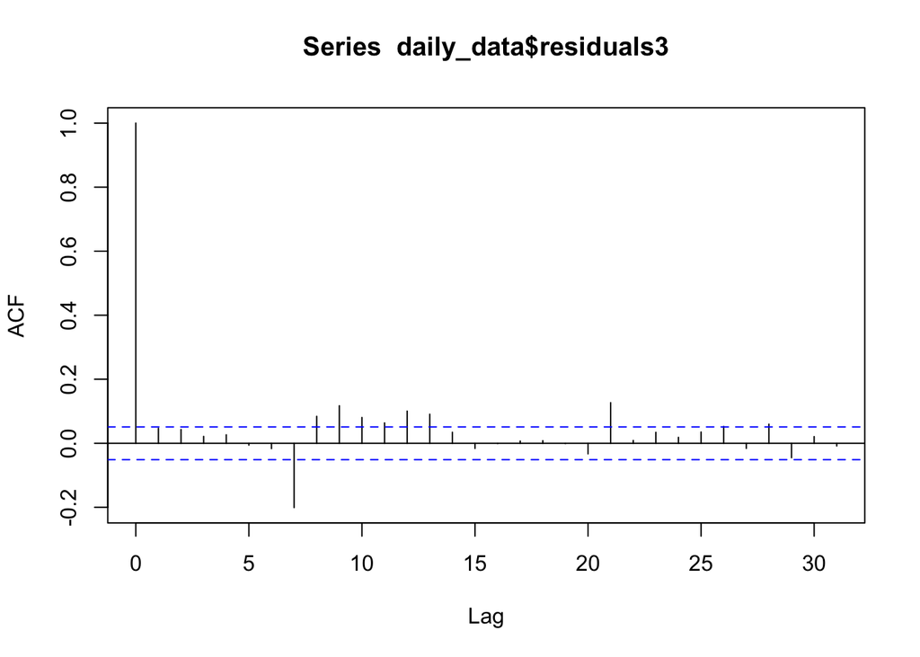

```r
daily_data[ , residuals3 := residuals(model3)  ]
daily_data[ , fitted3 :=  fitted2 + residuals(model3)]

acf(daily_data$residuals3)
```

```r
model4 =  arima(daily_data$residuals3 , order =  c(1,0,0))
summary(model4)
```

```
##
## Call:
## arima(x = daily_data$residuals3, order = c(1, 0, 0))
##
## Coefficients:
##          ar1  intercept
##       0.0468     4.9449
## s.e.  0.0261    21.7932
##
## sigma^2 estimated as 633593:  log likelihood = -11888.63,  aic = 23783.26
##
## Training set error measures:
##                      ME     RMSE      MAE      MPE     MAPE      MASE
## Training set 0.01653438 795.9855 537.0808 51.05178 170.1684 0.7642542
##                      ACF1
## Training set -0.001886775
```

```r
daily_data[ , residuals4 := residuals(model4)  ]
daily_data[ , fitted4 :=  fitted3 + residuals(model4)]


#acf(daily_data$residuals3)
```

Testing the Accuracy

In order to test this model, I built a naive forecasting model in order to compare with and checked their test statistics.

```r
daily_data[ , previous := shift( x = Consumption , n = 1L , fill = mean(Consumption))]

# %% index > 34896]
test = daily_data[ index < 35210 & index > 34896  ]

test_1= test[ , c(3,16)]
test_1 = data.table(test_1)
test_1
```

```
##     Consumption  fitted1
##  1:    34801.77 34618.21
##  2:    34377.73 34553.09
##  3:    32413.03 32862.40
##  4:    31293.02 31643.05
##  5:    33865.75 33490.89
##  6:    33610.11 34157.39
##  7:    33285.13 33546.87
##  8:    34801.77 33717.74
##  9:    34377.73 34278.24
## 10:    29643.70 32475.06
## 11:    30082.14 29572.38
## 12:    33465.78 32673.99
## 13:    33558.82 33176.54
## 14:    34098.38 33328.89
```

```r
test_2= test[ , c(3,17)]
test_2 = data.table(test_2)
test_2
```

```
##     Consumption  residuals1
##  1:    34801.77   183.55969
##  2:    34377.73  -175.36410
##  3:    32413.03  -449.37033
##  4:    31293.02  -350.03258
##  5:    33865.75   374.85555
##  6:    33610.11  -547.27575
##  7:    33285.13  -261.73845
##  8:    34801.77  1084.03040
##  9:    34377.73    99.49044
## 10:    29643.70 -2831.36090
## 11:    30082.14   509.76435
## 12:    33465.78   791.78674
## 13:    33558.82   382.28215
## 14:    34098.38   769.49289
```

```r
output <- function(actual, forecasted){
  n=length(actual)
  error = actual-forecasted
  mean=mean(actual)
  sd=sd(actual)
  bias = sum(error)/sum(actual)
  mape = sum(abs(error/actual))/n
  mad = sum(abs(error))/n
  wmape = mad/mean
  l = data.frame(n,mean,sd,bias,mape,mad,wmape)
  return(l)
}

#daily_data
#output(test_1$Consumption[1:14], test_1$fitted4[1:14])
#output(test_2$Consumption[1:14], test_2$previous[1:14])
```

Test results for actual model and naive model are as, n mean sd bias mape mad wmape 14 33119.63 1665.587 0.001842927 0.03927153 1258.182 0.037989 14 33119.63 1665.587 -0.0009408964 0.03997456 1289.901 0.03894671

Consclusion

After checking the error statisticts, comparing with a naive prediction model of previous day, we have a slightly better “wmape” value, states that our model is better than naive forecast and it is beneficial to use this prediction model.

References https://seffaflik.epias.com.tr/transparency/tuketim/gerceklesen-tuketim/gercek-zamanli-tuketim.xhtml (Consumption Data)